# Body Fat by Underwater Weighing

E.Gallo, M.Aljafari

06 aprile 2020

# Description

**Body fat** is expensive and unwieldy to measure directly, as it involves underwater weighing. Thus it would be highly desirable to predict this quantity from easily measurable variables such as **height**, **age**, **weight**, **abdome circumference** and so on.

This is a data frame containing the estimates of the percentage of body fat determined by underwater weighing (**fat_class**) and various body circumference measurements for 252 men.

## 1.

Let’s have a look at some characteristics of the variables and if there are any **NA** values:

```r
summary(bodyfat)
```

```
##       age            weight          height           neck
##  Min.   :22.00   Min.   :118.5   Min.   :29.50   Min.   :31.10
##  1st Qu.:35.75   1st Qu.:159.0   1st Qu.:68.25   1st Qu.:36.40
##  Median :43.00   Median :176.5   Median :70.00   Median :38.00
##  Mean   :44.88   Mean   :178.9   Mean   :70.15   Mean   :37.99
##  3rd Qu.:54.00   3rd Qu.:197.0   3rd Qu.:72.25   3rd Qu.:39.42
##  Max.   :81.00   Max.   :363.1   Max.   :77.75   Max.   :51.20
##      chest           abdomen            hip            thigh
##  Min.   : 79.30   Min.   : 69.40   Min.   : 85.0   Min.   :47.20
##  1st Qu.: 94.35   1st Qu.: 84.58   1st Qu.: 95.5   1st Qu.:56.00
##  Median : 99.65   Median : 90.95   Median : 99.3   Median :59.00
##  Mean   :100.82   Mean   : 92.56   Mean   : 99.9   Mean   :59.41
##  3rd Qu.:105.38   3rd Qu.: 99.33   3rd Qu.:103.5   3rd Qu.:62.35
##  Max.   :136.20   Max.   :148.10   Max.   :147.7   Max.   :87.30
##       knee           ankle          biceps         forearm
##  Min.   :33.00   Min.   :19.1   Min.   :24.80   Min.   :21.00
##  1st Qu.:36.98   1st Qu.:22.0   1st Qu.:30.20   1st Qu.:27.30
##  Median :38.50   Median :22.8   Median :32.05   Median :28.70
##  Mean   :38.59   Mean   :23.1   Mean   :32.27   Mean   :28.66
##  3rd Qu.:39.92   3rd Qu.:24.0   3rd Qu.:34.33   3rd Qu.:30.00
##  Max.   :49.10   Max.   :33.9   Max.   :45.00   Max.   :34.90
##      wrist       fat_class
##  Min.   :15.80   low :152
##  1st Qu.:17.60   high:100
##  Median :18.30
##  Mean   :18.23
##  3rd Qu.:18.80
##  Max.   :21.40
```

```r
anyNA(bodyfat)
```

```
## [1] FALSE
```

We note that in **height** variable there is a minimum value that is an error and that should be $69.5$ instead of $29.5$.

```r
#search for row number that has the mistake
bodyfat[bodyfat$height == 29.5,]
```

```
##    age weight height neck chest abdomen   hip thigh knee ankle biceps
## 42  44    205   29.5 36.6   106   104.3 115.5  70.6 42.5  23.7   33.6
##    forearm wrist fat_class
## 42    28.7  17.4      high
```

```r
#change the value
bodyfat[42,"height"] = 69.5

#check if it's good
bodyfat[42,]
```

```
##    age weight height neck chest abdomen   hip thigh knee ankle biceps
## 42  44    205   69.5 36.6   106   104.3 115.5  70.6 42.5  23.7   33.6
##    forearm wrist fat_class
## 42    28.7  17.4      high
```

## 2.a

Since we have a quite wide dataframe would be useless to plot **all the variables togheter**, so we split it in **half** and all the point will be divided in two different colors: **black** if they correspond to the factor value **low** of *fat_class* and **red** if they correspond to **high**

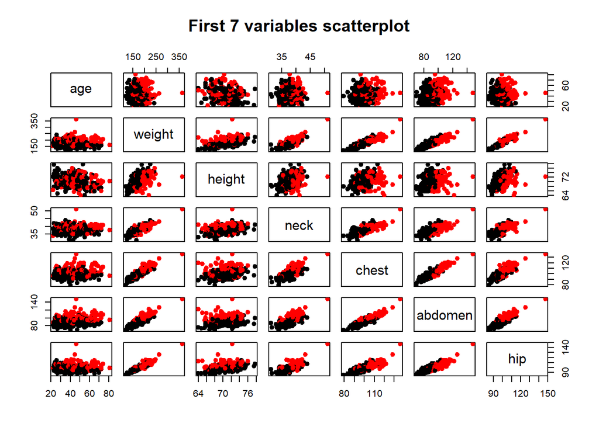

```r
plot(bodyfat[,1:7], col = bodyfat$fat_class, pch = 19, main = "First 7 variables scatterplot")
```

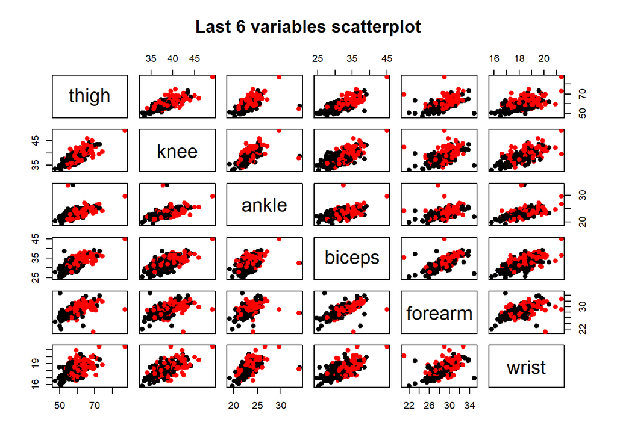

```r
plot(bodyfat[,8:13], col = bodyfat$fat_class, pch = 19, main = "Last 6 variables scatterplot")
```

## 2.b

We focus our attention on a subset of **bodyfat**, taking into account **weight**, **height** and **fat_class**.

```r
w_h <- bodyfat[,c("weight", "height", "fat_class")]
head(w_h)
```

```
##   weight height fat_class
## 1 154.25  67.75       low
## 2 173.25  72.25       low
## 3 154.00  66.25      high
## 4 184.75  72.25       low
## 5 184.25  71.25      high
## 6 210.25  74.75       low
```

On this subset we try to apply a linear classifier to see if it succesfully separate **low** from **high** in **fat_class**.

First we do a $70\%$/$30\%$ split of the dataset in Train-set and Test-set *“by hands”*

```r
intrain <- sample(1:dim(w_h)[1])
training <- w_h[intrain[1:floor(dim(w_h)[1]*0.7)], ]
testing <- w_h[intrain[ceiling(dim(w_h)[1]*0.7):dim(w_h)[1]], ]
```

We apply the function **svm()** from the **e1071** package, to fit a linear classifier with **fat_class** as response and **weight** and **height** as predictors.

```r
svm_model<- svm(fat_class ~ .,data = training,
                type = "C-classification",
                kernel = "linear",
                scale = FALSE)

#compute training accuracy
pred_train <- predict(svm_model, training)
mean(pred_train == training$fat_class)
```

```
## [1] 0.7443182
```

```r
#compute test accuracy
pred_test <- predict(svm_model, testing)
mean(pred_test == testing$fat_class)
```

```
## [1] 0.75
```

Let’s visualize the solution we obtained. We start from visualizing the support vectors on the **training** set

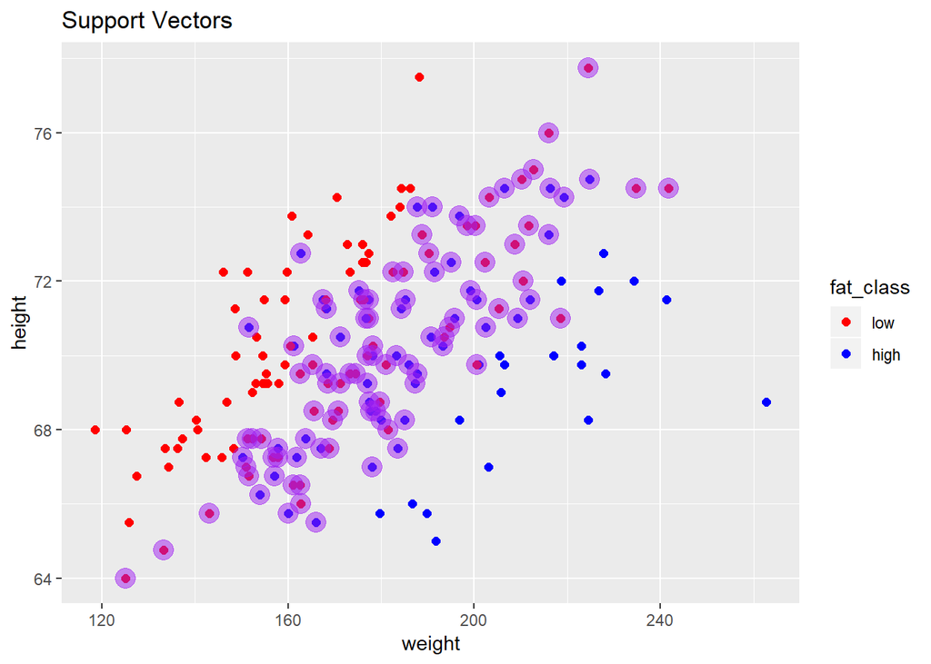

```r
scatter_plot <- ggplot(data = training, aes(x = weight, y = height, color = fat_class)) +
  geom_point(size = 2) +
  scale_color_manual(values = c("red", "blue")) +
  labs(title = "Support Vectors")
layered_plot <-
  scatter_plot + geom_point(data = training[svm_model$index,],
                            aes(x = weight, y = height), color = "purple",
                            size = 5, alpha = 0.5)
layered_plot
```

Now we add **decision and margin boundaries**

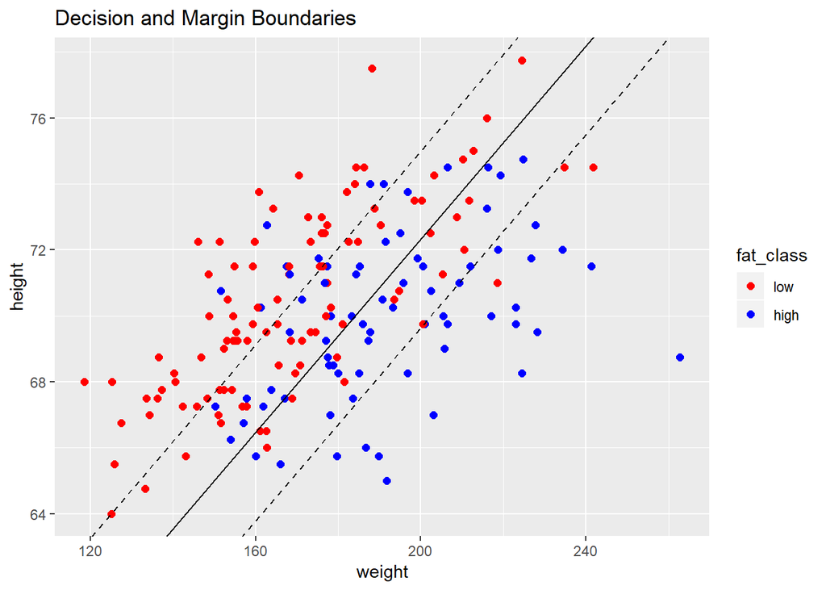

```r
#Find slope and intercept of the boundary
w <- t(svm_model$coefs) %*% svm_model$SV
slope_1 <- -w[1]/w[2]
intercept_1 <- svm_model$rho/w[2]
#build scatter plot of training dataset
scatter_plot <- ggplot(data = training, aes(x = weight, y = height, color = fat_class)) +
    geom_point(size = 2) + scale_color_manual(values = c("red", "blue"))
#add decision boundary
plot_decision <- scatter_plot + geom_abline(slope = slope_1, intercept = intercept_1)
#add margin boundaries
plot_margins <- plot_decision +
 geom_abline(slope = slope_1, intercept = intercept_1 - 1/w[2], linetype = "dashed")+
 geom_abline(slope = slope_1, intercept = intercept_1 + 1/w[2], linetype = "dashed") +
  labs(title = "Decision and Margin Boundaries")
#display plot
plot_margins
```

## 3.

Now we move to analyze the response variable **fat_class** using all variables as predictors.

We separate now the dataset in $70\%$/$30\%$ using **createDataPartition()** from the *caret* package.

```r
index <- createDataPartition(y = bodyfat$fat_class, p = 0.7, list = F)
bodytrain <- bodyfat[index,]
bodytest <- bodyfat[-index,]
```

## 4.

Now we’ll make our analisys through the **ksvm()** function from the **kernlab** package that seems to work better when number of features are very large. We use a *vanilladot* kernel and we apply the 5-fold cross validation.

```r
fat<- ksvm(fat_class~., data = bodytrain,kernel = "vanilladot" , cross = 5)
body <- predict(fat, bodytest[,-14])
confu <- confusionMatrix(table(body, bodytest[,14]))
confu
```

```
## Confusion Matrix and Statistics
##
##
## body   low high
##   low   39   11
##   high   6   19
##
##                Accuracy : 0.7733
##                  95% CI : (0.6621, 0.8621)
##     No Information Rate : 0.6
##     P-Value [Acc > NIR] : 0.001176
##
##                   Kappa : 0.5143
##
##  Mcnemar's Test P-Value : 0.331975
##
##             Sensitivity : 0.8667
##             Specificity : 0.6333
##          Pos Pred Value : 0.7800
##          Neg Pred Value : 0.7600
##              Prevalence : 0.6000
##          Detection Rate : 0.5200
##    Detection Prevalence : 0.6667
##       Balanced Accuracy : 0.7500
##
##        'Positive' Class : low
##
```

In the confusion matrix the good values are the ones on the main diagonal, on the other diagonal we have mistakes.

## 5.

In the end we try to find the best predictive model varying: the **C** value, that change how we deal with missclassified values, the **bigger** the C the **lesser** the missclassification and viceversa. Then we will vary all the **kernel function** that are in **ksvm()**

```r
ci <- c(2^-8, 2^-5, 2^-3, 2^-1, 1, 2, 2^3, 2^5, 2^8)
kernel <- c("polydot","rbfdot","tanhdot", "vanilladot",
            "laplacedot", "besseldot", "anovadot", "splinedot")
#create a dataframe to store data
df <- matrix(ncol = 3)
colnames(df) <- c("Kernel", "C", "Accuracy")
df <- as.data.frame(df)
accu <- list()
#iterate through kernels and Cs
for(j in kernel){
  for(i in ci){
    fat<- ksvm(fat_class~., data = bodytrain, C = i, kernel = j , cross = 5)
    body <- predict(fat, bodytest[,-14])
    confu <- confusionMatrix(table(body, bodytest[,14]))
    df <- rbind(df, c(j, i, confu$overall[["Accuracy"]]))
  }
}
```

```r
#get rid of the first row of NAs
df <- na.omit(df)
#look for maximum accuracy
maxi <- max(df$Accuracy)
df[df$Accuracy == maxi,]
```

```
##        Kernel   C          Accuracy
## 5     polydot 0.5 0.786666666666667
## 7     polydot   2 0.786666666666667
## 32 vanilladot 0.5 0.786666666666667
## 34 vanilladot   2 0.786666666666667
```

In the end we obtain the most accurate models